# 2_outliers_z_score_exercise

## Exercise: Outlier removal using standard deviation and z score

You are given bhp.csv which contains property prices in the city of banglore, India. You need to examine price_per_sqft column and do following,

(1) Remove outliers using percentile technique first. Use [0.001, 0.999] for lower and upper bound percentiles

(2) After removing outliers in step 1, you get a new dataframe.

(3) On step(2) dataframe, use 4 standard deviation to remove outliers

(4) Plot histogram for new dataframe that is generated after step (3). Also plot bell curve on same histogram

(5) On step(2) dataframe, use zscore of 4 to remove outliers. This is quite similar to step (3) and you will get exact same result

```python
import pandas as pd
import matplotlib
from matplotlib import pyplot as plt
%matplotlib inline
matplotlib.rcParams['figure.figsize'] = (12,8)
```

```python
df = pd.read_csv("bhp.csv")
df.head()
```

|  | location | size | total_sqft | bath | price | bhk | price_per_sqft |
| --- | --- | --- | --- | --- | --- | --- | --- |
| 0 | Electronic City Phase II | 2 BHK | 1056.0 | 2.0 | 39.07 | 2 | 3699 |
| 1 | Chikka Tirupathi | 4 Bedroom | 2600.0 | 5.0 | 120.00 | 4 | 4615 |
| 2 | Uttarahalli | 3 BHK | 1440.0 | 2.0 | 62.00 | 3 | 4305 |
| 3 | Lingadheeranahalli | 3 BHK | 1521.0 | 3.0 | 95.00 | 3 | 6245 |
| 4 | Kothanur | 2 BHK | 1200.0 | 2.0 | 51.00 | 2 | 4250 |

We will quickly examine price_per_sqft column to check min,max,mean and percentile values

```python
df.price_per_sqft.describe()
```

```
count    1.320000e+04
mean     7.920337e+03
std      1.067272e+05
min      2.670000e+02
25%      4.267000e+03
50%      5.438000e+03
75%      7.317000e+03
max      1.200000e+07
Name: price_per_sqft, dtype: float64
```

Above, you can see max is 12000000, which is too much price for price per sqft. Looks like this dataset has some very bad outliers so we will first remove those with percentile and then use z score

Also **plot histogram** to see how is the data distribution

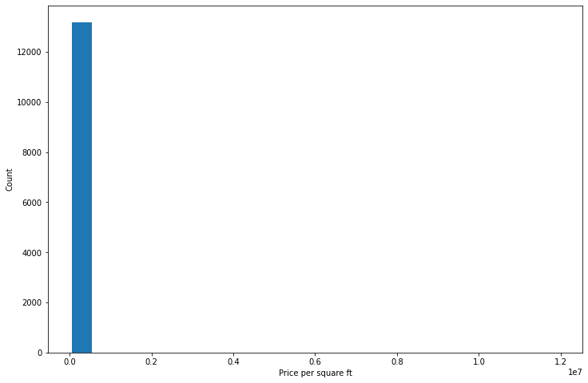

```python
plt.hist(df.price_per_sqft, bins=20, rwidth=0.8)
plt.xlabel('Price per square ft')
plt.ylabel('Count')
plt.show()
```

Above chart confirms our understanding that this dataset has some bad outliers. Because we see only one bar with more than 12000 data points but on the right hand side there are data points that have higher value for price per sqft but count of these data points is very tiny compared to 12000 hence we can hardly see any bar

Using **log scale** can make visualization little better

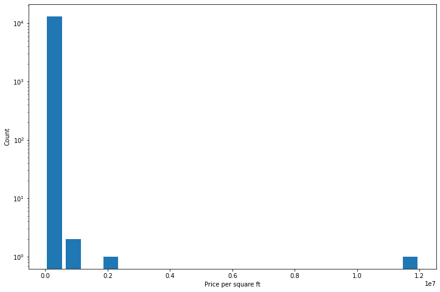

```python
plt.hist(df.price_per_sqft, bins=20, rwidth=0.8)
plt.xlabel('Price per square ft')
plt.ylabel('Count')
plt.yscale('log')
plt.show()
```

You see atleast few bars on right hand side of our highest building at least :)

### (1) Treat outliers using percentile first

```python
lower_limit, upper_limit = df.price_per_sqft.quantile([0.001, 0.999])
lower_limit, upper_limit
```

```
(1366.184, 50959.36200000098)
```

```python
outliers = df[(df.price_per_sqft>upper_limit) | (df.price_per_sqft<lower_limit)]
outliers.sample(10)
```

|  | location | size | total_sqft | bath | price | bhk | price_per_sqft |
| --- | --- | --- | --- | --- | --- | --- | --- |
| 665 | Yelahanka | 3 BHK | 35000.0 | 3.0 | 130.0 | 3 | 371 |
| 2392 | other | 4 Bedroom | 2000.0 | 3.0 | 25.0 | 4 | 1250 |
| 9436 | Indira Nagar | 4 Bedroom | 2400.0 | 5.0 | 1250.0 | 4 | 52083 |
| 12355 | other | 4 BHK | 16335.0 | 4.0 | 149.0 | 4 | 912 |
| 8307 | Bannerghatta Road | 5 BHK | 2500.0 | 4.0 | 1400.0 | 5 | 56000 |
| 5417 | Ulsoor | 4 BHK | 36000.0 | 4.0 | 450.0 | 4 | 1250 |
| 1005 | other | 1 BHK | 15.0 | 1.0 | 30.0 | 1 | 200000 |
| 7012 | other | 1 BHK | 650.0 | 1.0 | 500.0 | 1 | 76923 |
| 5343 | other | 9 BHK | 42000.0 | 8.0 | 175.0 | 9 | 416 |
| 7575 | other | 1 BHK | 425.0 | 1.0 | 750.0 | 1 | 176470 |

Above shows properties that has price_per_sqft value such as 500 rs which is very very low for the city of banglore. You would be very lucky if you can find such as property :) Also we have properties that has price per sqft value such as 12000000 which is way too high. It seems almost impossible and even if it is legitimate it can help data analysis process if we remove such a data point

```python
df2 = df[(df.price_per_sqft<upper_limit) & (df.price_per_sqft>lower_limit)]
df2.shape
```

```
(13172, 7)
```

```python
df.shape
```

```
(13200, 7)
```

```python
df.shape[0] - df2.shape[0]
```

```
28
```

**We removed total 28 outliers**

### (2) Now remove outliers using 4 standard deviation

```python
max_limit = df2.price_per_sqft.mean() + 4*df2.price_per_sqft.std()
min_limit = df2.price_per_sqft.mean() - 4*df2.price_per_sqft.std()
max_limit, min_limit
```

```
(23227.73653589432, -9900.429065502582)
```

```python
df2[(df2.price_per_sqft>max_limit) | (df2.price_per_sqft<min_limit)].sample(10)
```

|  | location | size | total_sqft | bath | price | bhk | price_per_sqft |
| --- | --- | --- | --- | --- | --- | --- | --- |
| 12799 | other | 5 Bedroom | 1650.0 | 5.0 | 450.0 | 5 | 27272 |
| 3752 | other | 4 Bedroom | 1200.0 | 4.0 | 300.0 | 4 | 25000 |
| 978 | Rajaji Nagar | 4 Bedroom | 315.0 | 4.0 | 90.0 | 4 | 28571 |
| 12900 | HAL 2nd Stage | 5 Bedroom | 2040.0 | 4.0 | 500.0 | 5 | 24509 |
| 9791 | other | 4 Bedroom | 1200.0 | 5.0 | 325.0 | 4 | 27083 |
| 3816 | Domlur | 6 BHK | 2400.0 | 4.0 | 600.0 | 6 | 25000 |
| 3401 | Indira Nagar | 6 Bedroom | 2480.0 | 4.0 | 750.0 | 6 | 30241 |
| 2632 | other | 4 Bedroom | 2400.0 | 4.0 | 700.0 | 4 | 29166 |
| 3136 | other | 4 Bedroom | 1200.0 | 4.0 | 350.0 | 4 | 29166 |
| 11838 | Vijayanagar | 4 Bedroom | 1500.0 | 4.0 | 360.0 | 4 | 24000 |

```python
df3 = df2[(df2.price_per_sqft>min_limit) & (df2.price_per_sqft<max_limit)]
df3.shape
```

```
(13047, 7)
```

```python
df2.shape[0]-df3.shape[0]
```

```
125
```

In this step we removed total 125 outliers

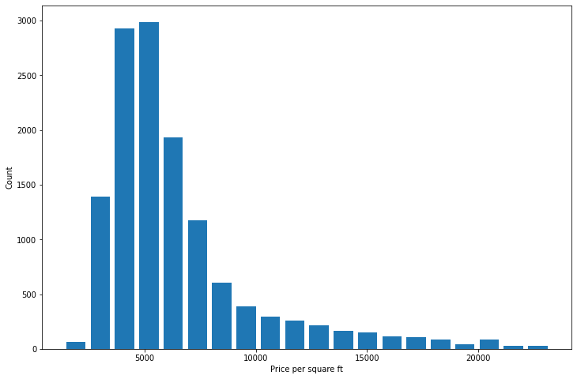

```python
plt.hist(df3.price_per_sqft, bins=20, rwidth=0.8)
plt.xlabel('Price per square ft')
plt.ylabel('Count')
plt.show()
```

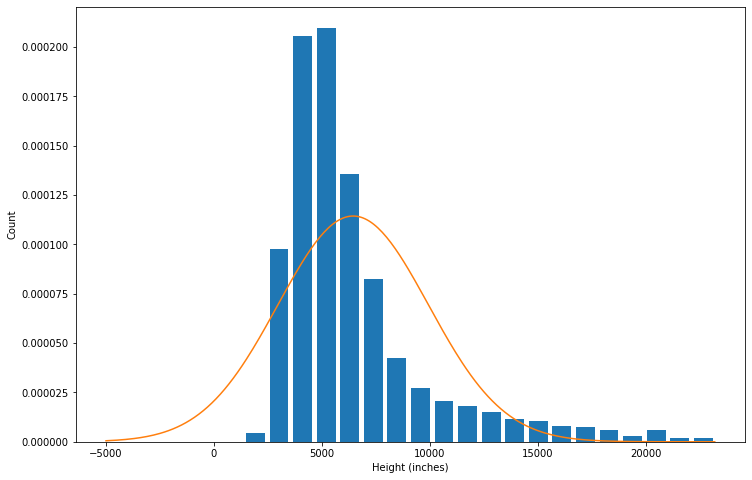

```python
from scipy.stats import norm
import numpy as np

plt.hist(df3.price_per_sqft, bins=20, rwidth=0.8, density=True)
plt.xlabel('Height (inches)')
plt.ylabel('Count')

rng = np.arange(-5000, df3.price_per_sqft.max(), 100)
plt.plot(rng, norm.pdf(rng,df3.price_per_sqft.mean(),df3.price_per_sqft.std()))
```

### (3) Now remove outliers using z score. Use z score of 4 as your thresold

```python
df2['zscore'] = (df2.price_per_sqft-df2.price_per_sqft.mean())/df2.price_per_sqft.std()
df2.sample(10)
```

|  | location | size | total_sqft | bath | price | bhk | price_per_sqft | zscore |
| --- | --- | --- | --- | --- | --- | --- | --- | --- |
| 11144 | Banashankari Stage VI | 3 BHK | 1392.0 | 3.0 | 69.46 | 3 | 4989 | -0.404406 |
| 11987 | NRI Layout | 2 Bedroom | 2400.0 | 2.0 | 125.00 | 2 | 5208 | -0.351521 |
| 6158 | Sarjapur Road | 3 BHK | 1455.0 | 2.0 | 98.00 | 3 | 6735 | 0.017229 |
| 12642 | other | 2 BHK | 1270.0 | 2.0 | 172.00 | 2 | 13543 | 1.661268 |
| 4530 | Kumaraswami Layout | 6 Bedroom | 610.0 | 4.0 | 95.00 | 6 | 15573 | 2.151486 |
| 11839 | Sanjay nagar | 2 BHK | 1050.0 | 2.0 | 59.00 | 2 | 5619 | -0.252270 |
| 6650 | Banashankari | 2 BHK | 1181.0 | 2.0 | 75.00 | 2 | 6350 | -0.075743 |
| 1429 | Sector 7 HSR Layout | 5 Bedroom | 900.0 | 4.0 | 90.00 | 5 | 10000 | 0.805682 |
| 11648 | other | 2 BHK | 830.0 | 2.0 | 26.00 | 2 | 3132 | -0.852846 |
| 5282 | Thanisandra | 2 BHK | 1230.0 | 2.0 | 44.00 | 2 | 3577 | -0.745385 |

```python
outliers_z = df2[(df2.zscore < -4) | (df2.zscore>4)]
outliers_z.shape
```

```
(125, 8)
```

```python
outliers_z.sample(5)
```

|  | location | size | total_sqft | bath | price | bhk | price_per_sqft | zscore |
| --- | --- | --- | --- | --- | --- | --- | --- | --- |
| 11661 | other | 4 Bedroom | 1200.0 | 4.0 | 375.0 | 4 | 31250 | 5.937267 |
| 9791 | other | 4 Bedroom | 1200.0 | 5.0 | 325.0 | 4 | 27083 | 4.930994 |
| 9907 | other | 8 Bedroom | 600.0 | 4.0 | 175.0 | 8 | 29166 | 5.434010 |
| 12051 | Malleshwaram | 5 Bedroom | 3000.0 | 4.0 | 900.0 | 5 | 30000 | 5.635409 |
| 10327 | Cunningham Road | 4 Bedroom | 7500.0 | 6.0 | 1800.0 | 4 | 24000 | 4.186491 |

```python
df4 = df2[(df2.zscore>-4)&(df2.zscore<4)]
df4.shape
```

```
(13047, 8)
```

```python
df2.shape[0] - df4.shape[0]
```

```
125
```

In this step also we removed 125 outliers. The result would be exactly same as 4 standard deviation